# Lab02

Xiaoya Li

```r
# load data in your R session
load('nba2017-salary-points.RData')
```

```r
# list the available objects with ls()
ls()
```

```
## [1] "player"   "points"   "points1"  "points2"  "points3"  "position"
## [7] "salary"   "team"
```

Your turn. Find out what is the class of each of the objects player, team, etc:

```r
class(player)
```

```
## [1] "character"
```

```r
class(team)
```

```
## [1] "factor"
```

```r
class(position)
```

```
## [1] "character"
```

```r
class(salary)
```

```
## [1] "numeric"
```

```r
class(points)
```

```
## [1] "integer"
```

Now use length(), head(), tail(), and summary() to start exploring the content of the objects:

```r
length(player)
```

```
## [1] 441
```

```r
head(player)
```

```
## [1] "Al Horford"        "Amir Johnson"      "Avery Bradley"
## [4] "Demetrius Jackson" "Gerald Green"      "Isaiah Thomas"
```

```r
tail(player)
```

```
## [1] "Leandro Barbosa" "Marquese Chriss" "Ronnie Price"    "T.J. Warren"
## [5] "Tyler Ulis"      "Tyson Chandler"
```

```r
summary(player)
```

```
##    Length     Class      Mode
##       441 character character
```

```r
length(team)
```

```
## [1] 441
```

```r
head(team)
```

```
## [1] BOS BOS BOS BOS BOS BOS
## 30 Levels: ATL BOS BRK CHI CHO CLE DAL DEN DET GSW HOU IND LAC LAL ... WAS
```

```r
tail(team)
```

```
## [1] PHO PHO PHO PHO PHO PHO
## 30 Levels: ATL BOS BRK CHI CHO CLE DAL DEN DET GSW HOU IND LAC LAL ... WAS
```

```r
summary(team)
```

```
## ATL BOS BRK CHI CHO CLE DAL DEN DET GSW HOU IND LAC LAL MEM MIA MIL MIN
##  14  15  15  15  15  15  15  15  15  15  14  14  15  15  15  14  14  14
## NOP NYK OKC ORL PHI PHO POR SAC SAS TOR UTA WAS
##  14  15  15  15  15  15  14  15  15  15  15  14
```

```r
summary(salary)
```

```
##     Min.  1st Qu.   Median     Mean  3rd Qu.     Max.
##     5145  1286160  3500000  6187014  9250000 30963450
```

```r
summary(points)
```

```
##    Min. 1st Qu.  Median    Mean 3rd Qu.    Max.
##     0.0   156.0   432.0   546.6   780.0  2558.0
```

Do all the objects have the same length? Yes.

```r
length(salary)
```

```
## [1] 441
```

```r
length(points)
```

```
## [1] 441
```

```r
length(position)
```

```
## [1] 441
```

How do you know if any of the loaded objects is a vector? Using class() does not explicitly tell you whether an R object is a vector or not. A more explicit way to check if player or position are vectors is with the function is.vector().

```r
# check whether the loaded objects are vectors
is.vector(player)
```

```
## [1] TRUE
```

```r
is.vector(team)
```

```
## [1] FALSE
```

```r
is.vector(salary)
```

```
## [1] TRUE
```

```r
is.vector(points)
```

```
## [1] TRUE
```

```r
is.vector(position)
```

```
## [1] TRUE
```

Remember that R vectors are atomic structures, which is just the fancy name to indicate that all the elements of a vector must be of the same type, either all numbers, all characters, or all logical values. To test if an object is atomic, i.e. has all its elements of the same type, use is.atomic()

```r
# check whether the loaded objects are atomic objects
is.atomic(player)
```

```
## [1] TRUE
```

```r
is.atomic(team)
```

```
## [1] TRUE
```

```r
is.atomic(salary)
```

```
## [1] TRUE
```

```r
is.atomic(points)
```

```
## [1] TRUE
```

```r
is.atomic(position)
```

```
## [1] TRUE
```

```r
# third element (four times)
player[rep(3, 4)]
```

```
## [1] "Avery Bradley" "Avery Bradley" "Avery Bradley" "Avery Bradley"
```

Subset the first four players:

```r
four <- player[1:4]
four
```

```
## [1] "Al Horford"        "Amir Johnson"      "Avery Bradley"
## [4] "Demetrius Jackson"
```

Now try these. What happens if you specify:

an index of zero: four[0]?  
a negative index: four[-1]?  
various negative indices: four[-c(1,2,3)]?  
an index greater than the length of the vector: four[5]?  
repeated indices: four[c(1,2,2,3,3,3)]?

```r
four[0]
```

```
## character(0)
```

```r
four[-1]             #all elements except 1
```

```
## [1] "Amir Johnson"      "Avery Bradley"     "Demetrius Jackson"
```

```r
four[-c(1,2,3)]      #all elements except 1,2,3
```

```
## [1] "Demetrius Jackson"
```

```r
four[5]
```

```
## [1] NA
```

```r
four[c(1,2,2,3,3,3)] #repeat as it indicate
```

```
## [1] "Al Horford"    "Amir Johnson"  "Amir Johnson"  "Avery Bradley"
## [5] "Avery Bradley" "Avery Bradley"
```

Figure out how to use seq(), rep() to extract:

all the even elements in player

```r
player_even <- player[seq(from = 2, to = length(player), by = 2)]
```

all the odd elements in salary

```r
salary_odd = salary[seq(from = 1, to = length(salary), by = 2)]
```

all multiples of 5 (e.g. 5, 10, 15, etc) of team

```r
team_muptiples_of_5 = team[seq(from = 5, to = length(team), by = 5)]
```

elements in positions 10, 20, 30, 40, etc of points

```r
points_in_10s_post = points[seq(from = 10, to = length(points), by = 10)]
```

all the even elements in team but this time in reverse order

```r
#team_even = team[seq(from = 2, to = length(team), by = 2)]
#team_even
team_even_reverse = team[seq(from = length(team), to = 2, by = -2)]
#team_even_reverse
```

Write commands, using bracket notation, to answer the following questions (you may need to use min(), max(), which(), which.min(), which.max()):

```r
# players in position Center, of Warriors (GSW)
player[position == 'C' & team == 'GSW']
```

```
## [1] "Damian Jones"  "David West"    "JaVale McGee"  "Kevon Looney"
## [5] "Zaza Pachulia"
```

```r
# players of both GSW (warriors) and LAL (lakers)
player[team == 'GSW' | team == 'LAL']
```

```
##  [1] "Andre Iguodala"       "Damian Jones"         "David West"
##  [4] "Draymond Green"       "Ian Clark"            "James Michael McAdoo"
##  [7] "JaVale McGee"         "Kevin Durant"         "Kevon Looney"
## [10] "Klay Thompson"        "Matt Barnes"          "Patrick McCaw"
## [13] "Shaun Livingston"     "Stephen Curry"        "Zaza Pachulia"
## [16] "Brandon Ingram"       "Corey Brewer"         "D'Angelo Russell"
## [19] "David Nwaba"          "Ivica Zubac"          "Jordan Clarkson"
## [22] "Julius Randle"        "Larry Nance Jr."      "Luol Deng"
## [25] "Metta World Peace"    "Nick Young"           "Tarik Black"
## [28] "Thomas Robinson"      "Timofey Mozgov"       "Tyler Ennis"
```

```r
# players in positions Shooting Guard and Point Guards, of Lakers (LAL)
player[team == 'LAL' & (position == 'SG' | position == 'PG')]
```

```
## [1] "D'Angelo Russell" "David Nwaba"      "Jordan Clarkson"
## [4] "Nick Young"       "Tyler Ennis"
```

```r
# subset Small Forwards of GSW and LAL
player[position == 'SF' & (team == 'GSW' | team == 'LAL')]
```

```
## [1] "Andre Iguodala"    "Kevin Durant"      "Matt Barnes"
## [4] "Brandon Ingram"    "Corey Brewer"      "Luol Deng"
## [7] "Metta World Peace"
```

```r
# name of the player with largest salary
player[salary == max(salary)]
```

```
## [1] "LeBron James"
```

```r
# name of the player with smallest salary
player[salary == min(salary)]
```

```
## [1] "Edy Tavares"
```

```r
# name of the player with largest number of points
player[points == max(points)]
```

```
## [1] "Russell Westbrook"
```

```r
# salary of the player with largest number of points
salary[points == max(points)]
```

```
## [1] 26540100
```

```r
# largest salary of all Centers
salary[position == 'C'][salary == max(salary)]
```

```
## [1] 6500000
```

```r
# team of the player with the largest number of points
team[player == player[points == max(points)]]
```

```
## [1] OKC
## 30 Levels: ATL BOS BRK CHI CHO CLE DAL DEN DET GSW HOU IND LAC LAL ... WAS
```

```r
# name of the player with the largest number of 3-pointers
player[points3 == max(points3)]
```

```
## [1] "Stephen Curry"
```

```r
names(player)
```

[output not shown]

Create a vector `warriors_player` by selecting the players of `team == 'GSW'`; then create a vector `warriors_salary` with their salaries, and another vector `warriors_points` with their `points`. Assign `warriors_player` as the names of `warriors_salary`.

```r
warriors_player <- player[team == 'GSW']
warriors_salary <- salary[team == 'GSW']
warriors_points <- points[team == 'GSW']
names(warriors_salary) <- warriors_player
```

You should have a vector `warriors_salary` with named elements. Now you can use character subsetting:

```r
warriors_salary["Andre Iguodala"]
```

```
## Andre Iguodala
##       11131368
```

```r
warriors_salary[c("Stephen Curry", "Kevin Durant")]
```

```
## Stephen Curry  Kevin Durant
##      12112359      26540100
```

Use the function `plot()` to make a scatterplot of `points` and `salary`

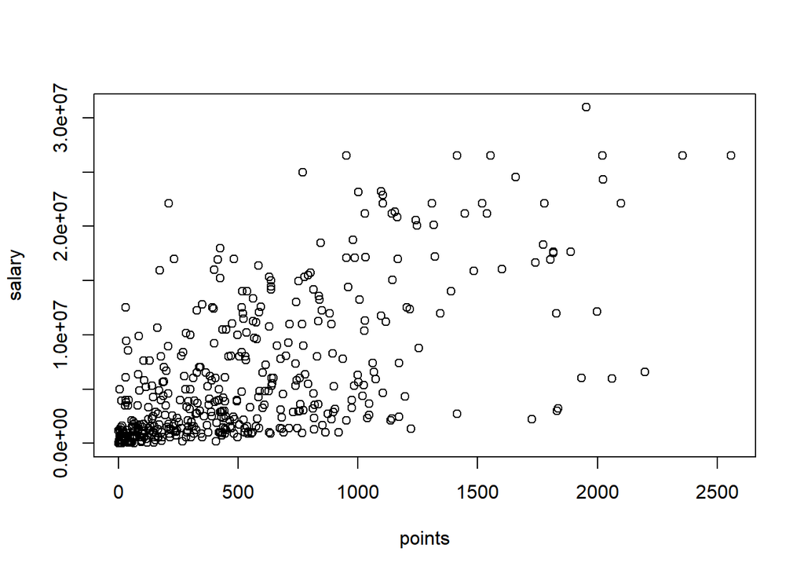

```r
plot(points, salary)
```

To get a better display of the scatterplot, let’s create two vectors `log_points` and `log_salary` by transforming `points` and `salary` with the logarithm function `log()`

```r
log_points <- log(points)
log_salary <- log(salary)
```

Make another scatterplot but now use the log-transformed vectors:

```r
plot(log_points, log_salary)
```

[output not shown]

To add the names of the players in the plot, you can use the low-level graphing function `text()`:

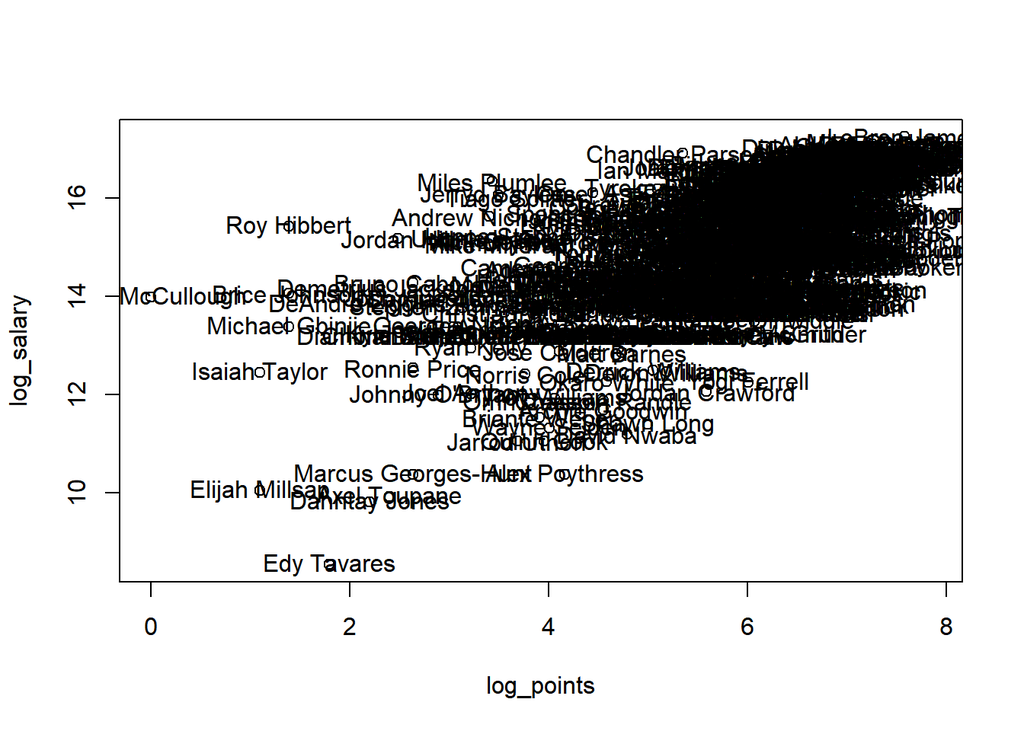

```r
plot(log_points, log_salary)
text(log_points, log_salary, labels = player)
```

Now we have another problem. The labels in the plot are very messy. A quick and dirty fix is to use `abbreviate()` to shorten the displayed names:

```r
plot(log_points, log_salary)
text(log_points, log_salary, labels = abbreviate(player))
```

[output not shown]

Your Turn: create a scatterplot of points and salary for the Warriors (GSW), displaying the names of the players. Generate two scatterplots, one with raw values (original scale, and another plot with log-transformations).

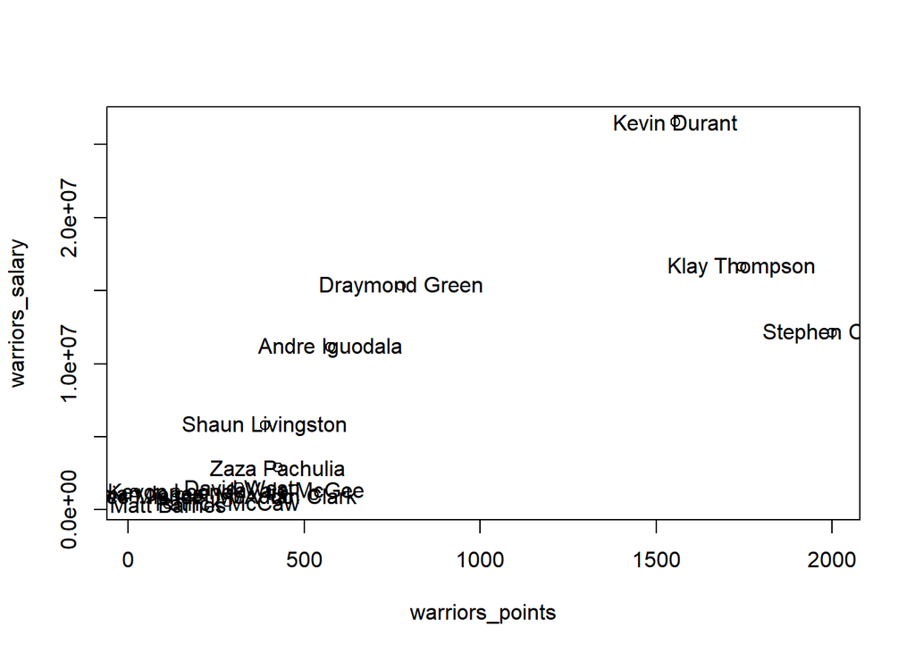

```r
#raw values
plot(warriors_points, warriors_salary)
text(warriors_points, warriors_salary, labels = warriors_player)
```

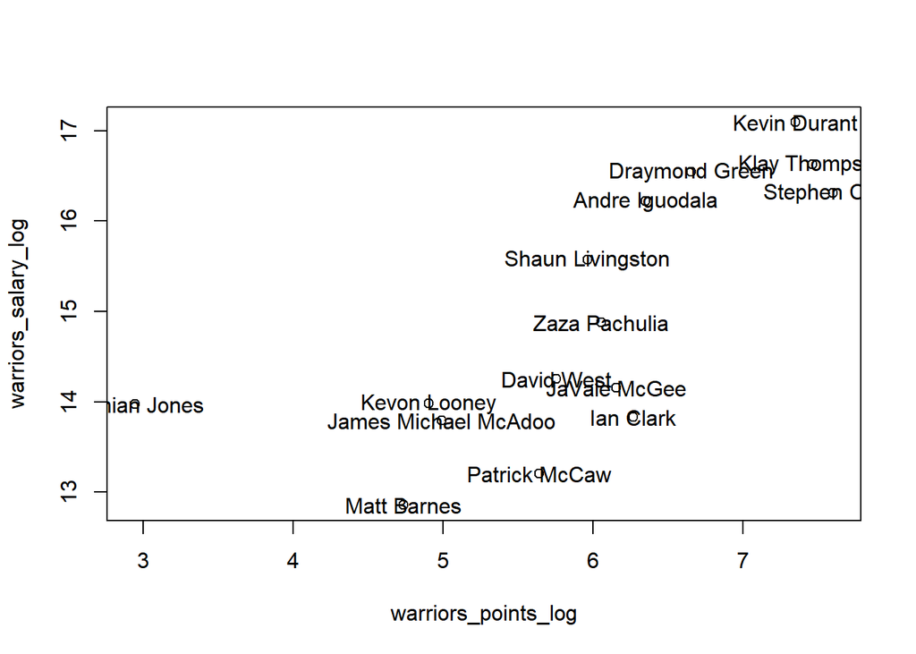

```r
#log-transformations
warriors_points_log <- log(warriors_points)
warriors_salary_log <- log(warriors_salary)
plot(warriors_points_log, warriors_salary_log)
text(warriors_points_log, warriors_salary_log, labels = warriors_player)
```

`salary` is given in dollars, but what if you need to obtain the salaries in millions of dollars?. Create a new vector `salary_millions` with the converted values in millions of dollars.

```r
# your code here
salary_millions <- salary / 1000000
```

Take the values in `height`, given in inches, to create a new vector `height_cms` that shows the values in centimeters; use the conversion of 1 inch = 2.54 centimeters.

```r
# your code here
height <- 10
height_cms <- height * 2.54
```

Here’s another example of recycling. Heights of elements in an odd number position will be transformed to cms; heights of elements in an even number position will be transformed to meters:

```r
units <- c(2.54, 0.0254)
mix_height <- height * units
```

The elements of `units` are recycled and repeated as many times as elements in `height`. The previous command is equivalent to this:

```r
new_units <- rep(c(2.54, 0.0254), length.out = length(height))
height * new_units
```

```
## [1] 25.4
```

The object `team` is an R factor. You can confirm this by using `is.factor()` or `class()`

```r
is.factor(team)
```

```
## [1] TRUE
```

Use `factor()` to create an object `position_fac` by converting `position` into a factor:

```r
position_fac <- factor(position)
```

If you have a factor, you can invoke `table()` to get a table with the frequencies (i.e. counts) of the factor categories or *levels*:

```r
table(position_fac)
```

```
## position_fac
##  C PF PG SF SG
## 89 89 85 83 95
```

### Manipulating Factors

Because factors are internally stored as integers, you can manipulate factors as any other vector:

```r
position_fac[1:5]
```

```
## [1] C  PF SG PG SF
## Levels: C PF PG SF SG
```

Practice manipulating `position_fac` to get:

```r
# positions of Warriors
position_fac[team == 'GSW']
```

```
##  [1] SF C  C  PF SG PF C  SF C  SG SF SG PG PG C
## Levels: C PF PG SF SG
```

```r
# positions of players with salaries > 15 millions
position_fac[salary > 15000000]
```

```
##  [1] C  PF PG SF C  SG SG C  PG C  SF PF C  SF SF SG SF PG C  C  PF SG SF
## [24] PG C  C  SG C  PF SF SG SF PF C  PG PF PF PG C  SF C  PG SF C  PG SG
## [47] PG SF SF C  C  PF PF SG SF C
## Levels: C PF PG SF SG
```

```r
# frequencies (counts) of positions with salaries > 15 millions
length(position_fac[salary > 15000000])
```

```
## [1] 56
```

```r
# relative frequencies (proportions) of 'SG' (Shooting Guards) in each team
prop.table(table(team[position_fac == 'SG']))
```

```
##
##        ATL        BOS        BRK        CHI        CHO        CLE
## 0.01052632 0.03157895 0.04210526 0.04210526 0.04210526 0.03157895
##        DAL        DEN        DET        GSW        HOU        IND
## 0.02105263 0.04210526 0.03157895 0.03157895 0.03157895 0.02105263
##        LAC        LAL        MEM        MIA        MIL        MIN
## 0.03157895 0.03157895 0.03157895 0.04210526 0.04210526 0.02105263
##        NOP        NYK        OKC        ORL        PHI        PHO
## 0.02105263 0.04210526 0.02105263 0.04210526 0.02105263 0.04210526
##        POR        SAC        SAS        TOR        UTA        WAS
## 0.04210526 0.05263158 0.05263158 0.03157895 0.02105263 0.03157895
```

Let’s go back to the scatterplot of `points` and `salary`

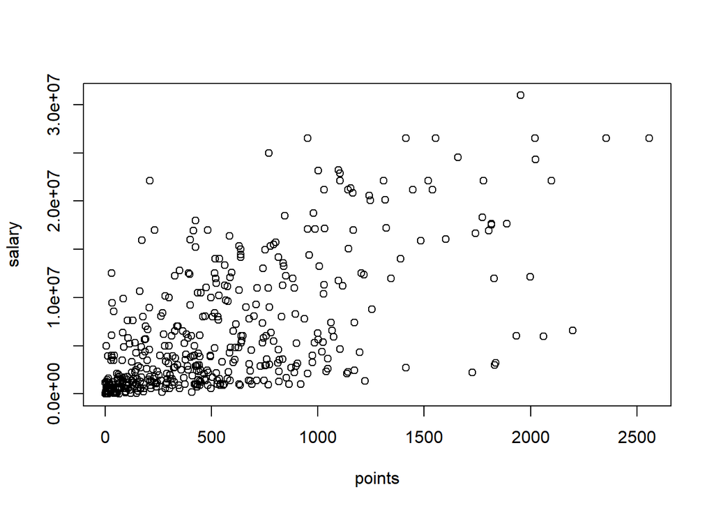

```r
plot(points, salary)
```

But now use your factor `position_fac` to add some color to the dots in the scatterplot. Pass the factor to the `col =` parameter inside `plot()`

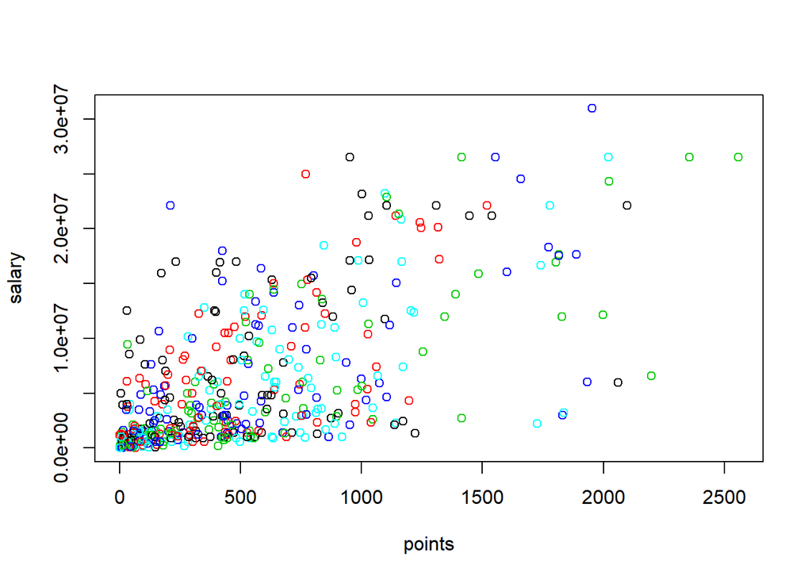

```r
# your colored scatterplot
plot(points, salary, col = position_fac )
```

Experiment with other `plot()` arguments like the *point character* `pch =`, the *size of dots* with the parameter `cex =`, the axes labels `xlab` and `ylab` and so on.

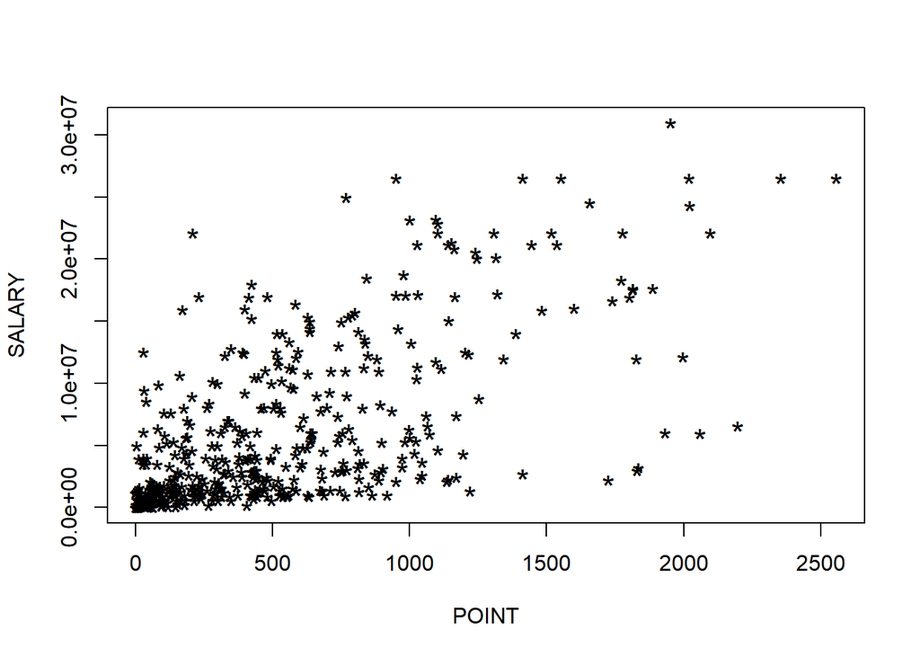

```r
plot(points, salary, pch = '*', cex = 1.5, xlab = 'POINT', ylab = 'SALARY')
```